# Reproducible Research: Peer Assessment 1

## Introduction

This R markdown file is a literate programming document that anwsers questions in the Peer Assessment 1 of the Coursera course Reproducible Research.

We follow the following conventions regarding citation:

- File names are put between “”.
- Names of R objects are *italicized*

We set the global options so that every code chunk is visible.

```r
library(knitr)
opts_chunk$set(echo=TRUE)
```

## Loading and preprocessing the data

It is important that we make sure that this R markdown file and the data file “activity.csv” are in the same work directory.

We load the data into a data frame *initialData*.

```r
initialData <- read.csv("activity.csv")
```

We check the structure and summary of the data frame *initialData*.

```r
str(initialData)
```

```
## 'data.frame':    17568 obs. of  3 variables:
##  $ steps   : int  NA NA NA NA NA NA NA NA NA NA ...
##  $ date    : Factor w/ 61 levels "2012-10-01","2012-10-02",..: 1 1 1 1 1 1 1 1 1 1 ...
##  $ interval: int  0 5 10 15 20 25 30 35 40 45 ...
```

```r
summary(initialData)
```

```
##      steps                date          interval
##  Min.   :  0.00   2012-10-01:  288   Min.   :   0.0
##  1st Qu.:  0.00   2012-10-02:  288   1st Qu.: 588.8
##  Median :  0.00   2012-10-03:  288   Median :1177.5
##  Mean   : 37.38   2012-10-04:  288   Mean   :1177.5
##  3rd Qu.: 12.00   2012-10-05:  288   3rd Qu.:1766.2
##  Max.   :806.00   2012-10-06:  288   Max.   :2355.0
##  NA's   :2304     (Other)   :15840
```

## What is mean total number of steps taken per day?

We use the dplyr package to compute the total steps of each day.

```r
library(dplyr)

stepsByDay <- initialData %>% group_by(date) %>% summarize(total_steps = sum(steps, na.rm =T))
str(stepsByDay)
```

```
## Classes 'tbl_df', 'tbl' and 'data.frame':    61 obs. of  2 variables:
##  $ date       : Factor w/ 61 levels "2012-10-01","2012-10-02",..: 1 2 3 4 5 6 7 8 9 10 ...
##  $ total_steps: int  0 126 11352 12116 13294 15420 11015 0 12811 9900 ...
##  - attr(*, "drop")= logi TRUE
```

```r
head(stepsByDay)
```

```
## Source: local data frame [6 x 2]
##
##         date total_steps
## 1 2012-10-01           0
## 2 2012-10-02         126
## 3 2012-10-03       11352
## 4 2012-10-04       12116
## 5 2012-10-05       13294
## 6 2012-10-06       15420
```

The following is a histogram of the total number of steps taken each day.

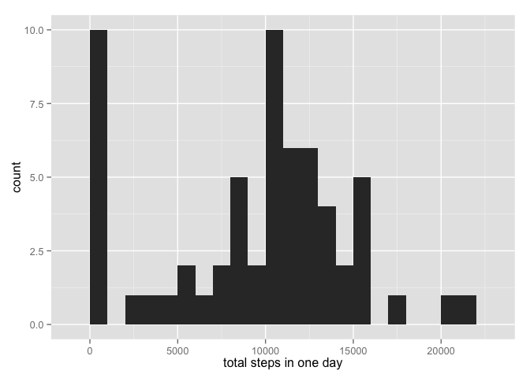

```r
library(ggplot2)

qplot(total_steps, data=stepsByDay, xlab="total steps in one day",binwidth = 1000)
```

```r
steps <- as.numeric(stepsByDay$total_steps)
mean <- mean(steps)
median <- quantile(steps, probs=0.5)
```

The mean is 9354, and the median is 10395.

## What is the average daily activity pattern?

We get the average number of steps taken in each interval averaged across all days by the following R code.

```r
stepsByInt <- initialData %>% group_by(interval) %>% summarize(average_steps = mean(steps, na.rm =T))
head(stepsByInt)
```

```
## Source: local data frame [6 x 2]
##
##   interval average_steps
## 1        0     1.7169811
## 2        5     0.3396226
## 3       10     0.1320755
## 4       15     0.1509434
## 5       20     0.0754717
## 6       25     2.0943396
```

```r
tail(stepsByInt)
```

```
## Source: local data frame [6 x 2]
##
##   interval average_steps
## 1     2330     2.6037736
## 2     2335     4.6981132
## 3     2340     3.3018868
## 4     2345     0.6415094
## 5     2350     0.2264151
## 6     2355     1.0754717
```

The following is a time series plotof the 5-minute interval (x-axis) and the average number of steps taken, averaged across all days (y-axis).

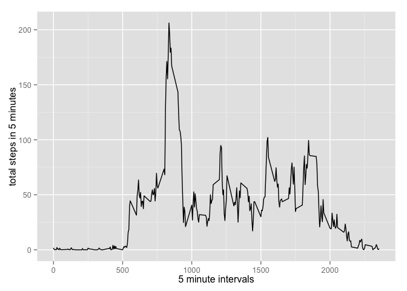

```r
qplot(y=average_steps, x= interval, data=stepsByInt, ylab="total steps in 5 minutes",xlab="5 minute intervals", geom="line")
```

The 5-minute interval that, on average across all the days in the dataset, contains the maximum number of step is the interval 835.

## Imputing missing values

We calculate the total number of missing values in the dataset (i.e. the total number of rows with NAs) with the following R code.

```r
totalNA <- sum(is.na(initialData$steps))
totalNA
```

```
## [1] 2304
```

```r
#initialData <- arrange(initialData, interval)

newData <- merge(initialData, stepsByInt, by.x="interval", by.y="interval", all = T)
newData$steps[is.na(newData$steps)] <- newData$average_steps[is.na(newData$steps)]

newData <- select(newData, steps,date,interval)

head(newData)
```

```
##      steps       date interval
## 1 1.716981 2012-10-01        0
## 2 0.000000 2012-11-23        0
## 3 0.000000 2012-10-28        0
## 4 0.000000 2012-11-06        0
## 5 0.000000 2012-11-24        0
## 6 0.000000 2012-11-15        0
```

```r
str(newData)
```

```
## 'data.frame':    17568 obs. of  3 variables:
##  $ steps   : num  1.72 0 0 0 0 ...
##  $ date    : Factor w/ 61 levels "2012-10-01","2012-10-02",..: 1 54 28 37 55 46 20 47 38 56 ...
##  $ interval: int  0 0 0 0 0 0 0 0 0 0 ...
```

We caculate the total number of steps taken each day and plot a histogram of the total number of steps taken each day.

```r
NstepsByDay <- newData %>% group_by(date) %>% summarize(total_steps = sum(steps))

str(NstepsByDay)
```

```
## Classes 'tbl_df', 'tbl' and 'data.frame':    61 obs. of  2 variables:
##  $ date       : Factor w/ 61 levels "2012-10-01","2012-10-02",..: 1 2 3 4 5 6 7 8 9 10 ...
##  $ total_steps: num  10766 126 11352 12116 13294 ...
##  - attr(*, "drop")= logi TRUE
```

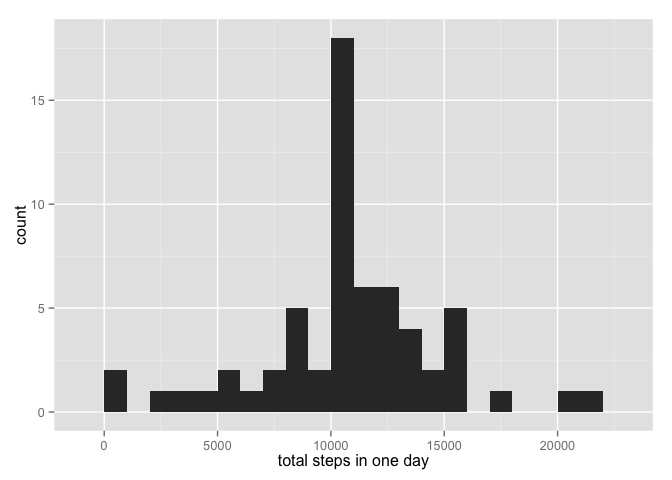

```r
qplot(total_steps, data=NstepsByDay, xlab="total steps in one day",binwidth = 1000)
```

```r
Nsteps <- as.numeric(NstepsByDay$total_steps)
Nmean <- mean(Nsteps)
Nmedian <- quantile(Nsteps, probs=0.5)
```

The mean is 10766, and the median is 10766.

The new values are larger than the estimates from the first part of the assignment. Another impact of imputing missing data on the estimates of the total daily number of steps is that the distribution of total steps of each day is more centerlized and has smaller variance which is shown in the following table.

```r
print(c( "variance with missing values"= var(steps), "variance after imputing missing values"=var(Nsteps)))
```

```
##           variance with missing values
##                               29223702
## variance after imputing missing values
##                               15795782
```

## Are there differences in activity patterns between weekdays and weekends?

First we need to convert the date variable which has a factor class into date class. Then we create a new factor variable “group” in the dataset with two levels “weekday” and “weekend” indicating whether a given date is a weekday or weekend day. The dataset is *group_interval_average* produced by the following R code.

```r
#First we need to convert the date variable which has a factor class into date
#class."%Y%m%d"
newData <- mutate(newData, date = as.Date(as.character(date)))

#str(newData)

group_interval_average <- newData %>% mutate(group = factor(weekdays(date) %in% c("Saturday","Sunday"),labels=c("weekday","weekend"))) %>% group_by(group, interval) %>% summarize(average_step = mean(steps))

str(group_interval_average)
```

```
## Classes 'grouped_df', 'tbl_df', 'tbl' and 'data.frame':  576 obs. of  3 variables:
##  $ group       : Factor w/ 2 levels "weekday","weekend": 1 1 1 1 1 1 1 1 1 1 ...
##  $ interval    : int  0 5 10 15 20 25 30 35 40 45 ...
##  $ average_step: num  2.251 0.445 0.173 0.198 0.099 ...
##  - attr(*, "vars")=List of 1
##   ..$ : symbol group
##  - attr(*, "drop")= logi TRUE
```

```r
head(group_interval_average)
```

```
## Source: local data frame [6 x 3]
## Groups: group
##
##     group interval average_step
## 1 weekday        0   2.25115304
## 2 weekday        5   0.44528302
## 3 weekday       10   0.17316562
## 4 weekday       15   0.19790356
## 5 weekday       20   0.09895178
## 6 weekday       25   1.59035639
```

The following is a time series plotof the 5-minute interval (x-axis) and the average number of steps taken, averaged across all weekday days or weekend days (y-axis).

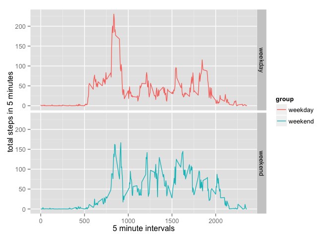

```r
qplot(y=average_step, x= interval, data=group_interval_average, ylab="total steps in 5 minutes",xlab="5 minute intervals",color=group, geom="line", facets=group ~.)
```